# Métodos Cuantitativos en Ecología - MCE5

EXAMEN FINAL - 2022II

David Grefa

2023-07-24

Los contenidos de esta evaluación corresponden a los temas:

- GLM y GAM
- Introducción a estadística Bayesiana
- Series de tiempo
- Análisis espacial

Ustedes estan utilizando un archivo tipo R Markdown (`.Rmd`). Las instruciones son **[1 PUNTO]**::

- Bifurquen el repositorio en GitHub y clonen en su computador usando un proyecto con control de la versión de RStudio.
- Arriba, donde dice “author”, deben llenar sus nombres.
- **Todo resultado debe ir con su explicación y/o discusión, caso contrario no se calificará.**
- **NO IMPRIMA los datos o tablas completas**, reporte únicamente figuras o tablas resumen. Si tiene varias figuras use la función `ggarrange` de la librería `ggpubr`.
- Al final de este examen deben utilizar el comando “Knit” para generar un archivo HTML.
- **Cada pregunta debe tener al menos un cntrol de la versión**.
- Su entrega consiste en colocar el **enlace de GitHub** en la actividad “ExamenFinal”.

## **PREGUNTA 1: GLM, GAM y Regresión Bayesiana [3 PUNTOS]**

En el archivo `"glm.xlsx"` tiene tres datos:

- aedes: insecticidas utilizados para controlar el número de mosquitos en un experimento. Cada vez que se repite la aplicación del insecticida parece disminuir la cantidad de zancudos vivos.
- leishmania: en una infección con leishmania cuando se analiza el tejido qué sucede con la concentración de algunas células y si están o no afectadas.
- disease: cómo la edad afecta a diferentes características dicotómicas.

Realice los siguientes análisis:

- aedes: GLM Poisson
- disease: GLMs binomiales
- leishmania: glm bayesiano

Realizar los siguientes análisis y respectivas interpretaciones:

1. Análisis exploratorio.
2. Planteamiento de hipótesis.
3. Análisis de regresión
4. Planteamiento del modelo.
5. Validez del modelo.

#1_Análisis exploratorio

```r
library(readxl)
glm <- read_excel("glm.xlsx")
View(glm)
head(glm)
```

```
## # A tibble: 6 × 3
##   agrochem repetition aedes
##   <chr>         <dbl> <dbl>
## 1 A                 1  2370
## 2 B                 1  1282
## 3 C                 1   562
## 4 D                 1   173
## 5 E                 1   193
## 6 A                 2  1687
```

```r
str(glm)
```

```
## tibble [30 × 3] (S3: tbl_df/tbl/data.frame)
##  $ agrochem  : chr [1:30] "A" "B" "C" "D" ...
##  $ repetition: num [1:30] 1 1 1 1 1 2 2 2 2 2 ...
##  $ aedes     : num [1:30] 2370 1282 562 173 193 ...
```

```r
summary(glm)
```

```
##    agrochem           repetition      aedes
##  Length:30          Min.   :1.0   Min.   :  44.0
##  Class :character   1st Qu.:2.0   1st Qu.: 136.5
##  Mode  :character   Median :3.5   Median : 523.5
##                     Mean   :3.5   Mean   : 865.4
##                     3rd Qu.:5.0   3rd Qu.:1217.8
##                     Max.   :6.0   Max.   :3020.0
```

**descripción** Se realizó un análisis exploratorio de la data glm, esta data contiene información de insecticidas para controlar el número de mosquitos, donde se cargo la data, se usó la librería readxl, con view(glm) se visualizó la información, head(glm) para visualizar los primeros 6 datos, str(glm) para visualizar si las variables son numéricas o categóricas.

En el resumen estadístistico se puede observar como se distriubuyen los datos de acuerdo a las variables en ese caso se ve que la repetición va de 1 a 6, donde el número de repeticiones mínimo es 1 y el máximo 6. Aedes muestra la cantidad de mosquitos que ha sobrevivido de acuerdo al número de repeticiones y a los tipos de insecticidas aplicados el valor más bajo de insectos sobrevivientes es 44 y el más alto(máximo) es de 3020 mosquitos vivos.

#2_Planteamiento de hipótesis para cada modelo

**hipótesis**la Aplicación repetida de insecticidas en un experimento para controlar el número de mosquitos de Aedes reduce efectivamente su población.

**Hipótesis**: Las variables relacionadas con la concentración y afectación de ciertas células se relacionan con la presencia/ausencia de infección causad por leishmania.

**Hipótesis**: La edad tiene un efecto en la presencia o ausencia de las variables

#Análisis GLM poisson en aedes

```r
glm <- read_excel("glm.xlsx", sheet = "aedes")
View(glm)

# Convertir la variable a factor
glm$agrochem <- factor(glm$agrochem)

# Análisis GLM Poisson
glm_poisson_model <- glm(aedes ~ agrochem + repetition, data = glm, family = poisson)
summary(glm_poisson_model)
```

```
##
## Call:
## glm(formula = aedes ~ agrochem + repetition, family = poisson,
##     data = glm)
##
## Coefficients:
##              Estimate Std. Error z value Pr(>|z|)
## (Intercept)  7.720708   0.015380 502.008  < 2e-16 ***
## agrochemB   -0.834727   0.014911 -55.982  < 2e-16 ***
## agrochemC   -1.547287   0.019582 -79.017  < 2e-16 ***
## agrochemD   -2.762813   0.033666 -82.066  < 2e-16 ***
## agrochemE   -3.300288   0.043497 -75.873  < 2e-16 ***
## repetition   0.026590   0.003636   7.312 2.63e-13 ***
## ---
## Signif. codes:  0 '***' 0.001 '**' 0.01 '*' 0.05 '.' 0.1 ' ' 1
##
## (Dispersion parameter for poisson family taken to be 1)
##
##     Null deviance: 26630.9  on 29  degrees of freedom
## Residual deviance:  1329.9  on 24  degrees of freedom
## AIC: 1579.4
##
## Number of Fisher Scoring iterations: 4
```

```r
# Visualizar los coeficientes estimados del modelo
coef(glm_poisson_model)
```

```
## (Intercept)   agrochemB   agrochemC   agrochemD   agrochemE  repetition
##  7.72070788 -0.83472749 -1.54728668 -2.76281295 -3.30028761  0.02658992
```

```r
print(glm_poisson_model)
```

```
##
## Call:  glm(formula = aedes ~ agrochem + repetition, family = poisson,
##     data = glm)
##
## Coefficients:
## (Intercept)    agrochemB    agrochemC    agrochemD    agrochemE   repetition
##     7.72071     -0.83473     -1.54729     -2.76281     -3.30029      0.02659
##
## Degrees of Freedom: 29 Total (i.e. Null);  24 Residual
## Null Deviance:       26630
## Residual Deviance: 1330  AIC: 1579
```

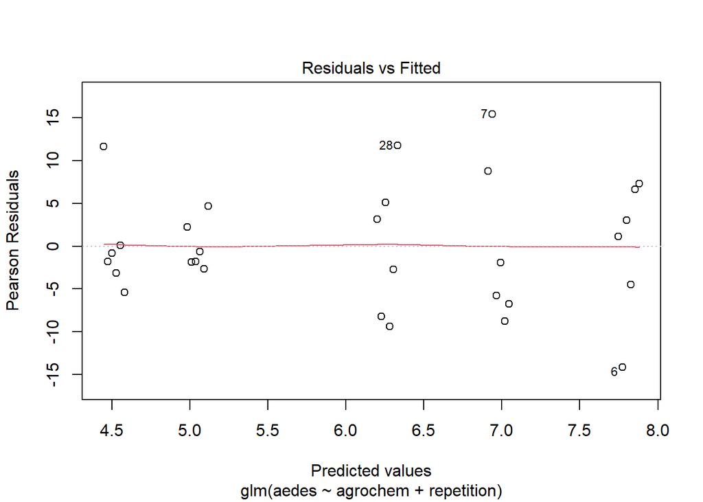

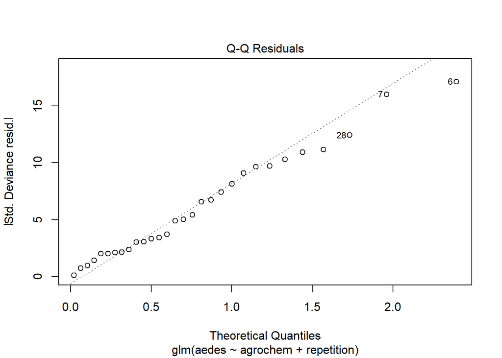

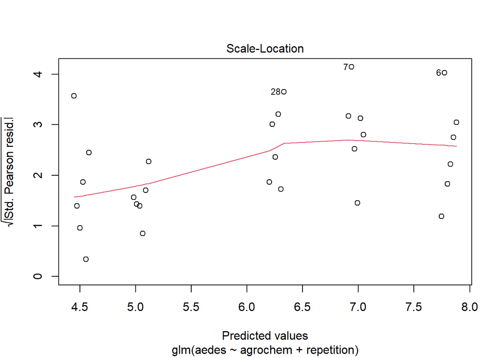

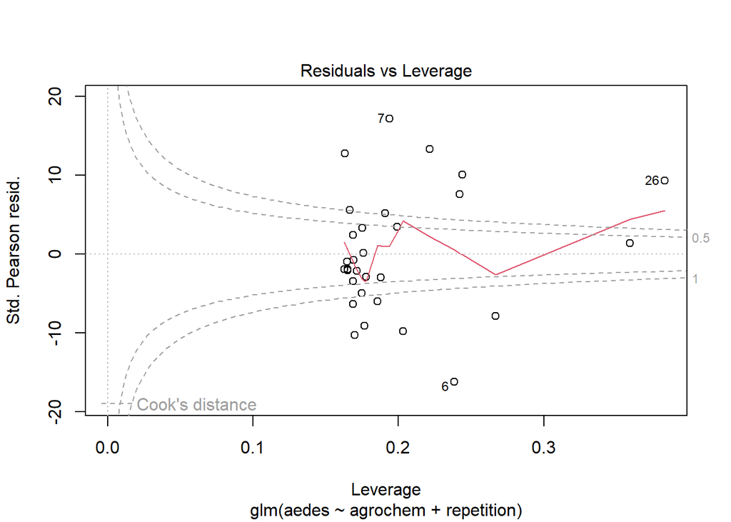

```r
#vizualización
plot(glm_poisson_model)
```

```r
#Calcular AIC del modelo
AIC(glm_poisson_model)
```

```
## [1] 1579.352
```

#Análisis GLMs binomiales en disease

```r
library(readxl)
library(dplyr)
```

```r
library(ggplot2)

# Cargar los datos
glm_disease <- read_excel("glm.xlsx", sheet = "disease")

# Convertir las variables a factor
glm_disease$native <- factor(glm_disease$native)
glm_disease$gender <- factor(glm_disease$gender)
glm_disease$treatment <- factor(glm_disease$treatment)
glm_disease$recover <- factor(glm_disease$recover)

# Realizar el análisis GLM binomial
glm_binomial_model <- glm(recover ~ native + gender + treatment + age, data = glm_disease, family = binomial(link = "logit"))

# Obtener un resumen del modelo
summary(glm_binomial_model)
```

```
##
## Call:
## glm(formula = recover ~ native + gender + treatment + age, family = binomial(link = "logit"),
##     data = glm_disease)
##
## Coefficients:
##             Estimate Std. Error z value Pr(>|z|)
## (Intercept) -2.31293    0.64259  -3.599 0.000319 ***
## native1      0.40879    0.59900   0.682 0.494954
## gender1     -0.30525    0.60413  -0.505 0.613362
## treatment1   1.57475    0.50162   3.139 0.001693 **
## age          0.02975    0.01350   2.203 0.027577 *
## ---
## Signif. codes:  0 '***' 0.001 '**' 0.01 '*' 0.05 '.' 0.1 ' ' 1
##
## (Dispersion parameter for binomial family taken to be 1)
##
##     Null deviance: 122.32  on 97  degrees of freedom
## Residual deviance: 101.05  on 93  degrees of freedom
## AIC: 111.05
##
## Number of Fisher Scoring iterations: 4
```

```r
# Visualizar los coeficientes del modelo
coef(glm_binomial_model)
```

```
## (Intercept)     native1     gender1  treatment1         age
## -2.31293482  0.40879024 -0.30525456  1.57474923  0.02975009
```

```r
print(glm_binomial_model)
```

```
##
## Call:  glm(formula = recover ~ native + gender + treatment + age, family = binomial(link = "logit"),
##     data = glm_disease)
##
## Coefficients:
## (Intercept)      native1      gender1   treatment1          age
##    -2.31293      0.40879     -0.30525      1.57475      0.02975
##
## Degrees of Freedom: 97 Total (i.e. Null);  93 Residual
## Null Deviance:       122.3
## Residual Deviance: 101.1     AIC: 111.1
```

```r
# Calcular el AIC del modelo
AIC(glm_binomial_model)
```

```
## [1] 111.0542
```

```r
# Calcular el BIC del modelo
BIC(glm_binomial_model)
```

```
## [1] 123.979
```

**descripción** Se cargó la data y luego a las varibales native, gender, treatment y recover se las convirtio a factor para indicarle al modelo de que son variables categóricas y no numéricas .Las variables “native”, “gender”, “treatment” y “age” tienen efectos diferentes en la variable de respuesta “recover”. El intercepto muestra una menor probabilidad de recuperación en ausencia de otras variables predictoras. El tratamiento se asocia con una mayor probabilidad de recuperación, mientras que la edad también influye de forma positiva enn en esta probabilidad. Según AIC y BIC son buenos modelos que se ajustan a los datos

```r
# Cargar las librerías necesarias
library(readxl)
library(dplyr)
library(rstanarm)
# Cargar los datos
glm_disease <- read_excel("glm.xlsx", sheet = "disease")

# Realizar el análisis GLM bayesiano
bayesian_glm_model <- stan_glm(recover ~ native + gender + treatment + age, data = glm_disease, family = binomial(link = "logit"))
# Obtener un resumen del modelo bayesiano
summary(bayesian_glm_model)
```

```
##
## Model Info:
##  function:     stan_glm
##  family:       binomial [logit]
##  formula:      recover ~ native + gender + treatment + age
##  algorithm:    sampling
##  sample:       4000 (posterior sample size)
##  priors:       see help('prior_summary')
##  observations: 98
##  predictors:   5
##
## Estimates:
##               mean   sd   10%   50%   90%
## (Intercept) -2.4    0.7 -3.3  -2.4  -1.6
## native       0.4    0.6 -0.4   0.4   1.2
## gender      -0.3    0.6 -1.1  -0.4   0.4
## treatment    1.7    0.5  1.0   1.6   2.3
## age          0.0    0.0  0.0   0.0   0.0
##
## Fit Diagnostics:
##            mean   sd   10%   50%   90%
## mean_PPD 0.3    0.1  0.2   0.3   0.4
##
## The mean_ppd is the sample average posterior predictive distribution of the outcome variable (for details see help('summary.stanreg')).
##
## MCMC diagnostics
##               mcse Rhat n_eff
## (Intercept)   0.0  1.0  2617
## native        0.0  1.0  3420
## gender        0.0  1.0  3107
## treatment     0.0  1.0  3139
## age           0.0  1.0  3834
## mean_PPD      0.0  1.0  4564
## log-posterior 0.0  1.0  1954
##
## For each parameter, mcse is Monte Carlo standard error, n_eff is a crude measure of effective sample size, and Rhat is the potential scale reduction factor on split chains (at convergence Rhat=1).
```

```r
# Obtener información sobre las distribuciones previas utilizadas en el modelo bayesiano
prior_summary(bayesian_glm_model)
```

```
## Priors for model 'bayesian_glm_model'
## ------
## Intercept (after predictors centered)
##  ~ normal(location = 0, scale = 2.5)
##
## Coefficients
##   Specified prior:
##     ~ normal(location = [0,0,0,...], scale = [2.5,2.5,2.5,...])
##   Adjusted prior:
##     ~ normal(location = [0,0,0,...], scale = [5.78,5.16,5.08,...])
## ------
## See help('prior_summary.stanreg') for more details
```

## **PREGUNTA 2: Series de tiempo [3 PUNTOS]**

En el archivo `"ts.xlsx"` tiene tres datos:

- quakes: cantidad de eventos de terremotos por cada año.
- hepatitis: casos de hepatitis por mes entre 2010 y 2017 (acomodar la tabla si es necesario)
- wildfire: cantidad de eventos de incendios forestales por mes entre 2003 y 2017.

Realizar los siguientes análisis y respectivas interpretaciones:

1. Análisis exploratorio: autocorrelación y descomposición, análisis estacional. ##QUAKES

```r
library(readxl)
library(forecast)
```

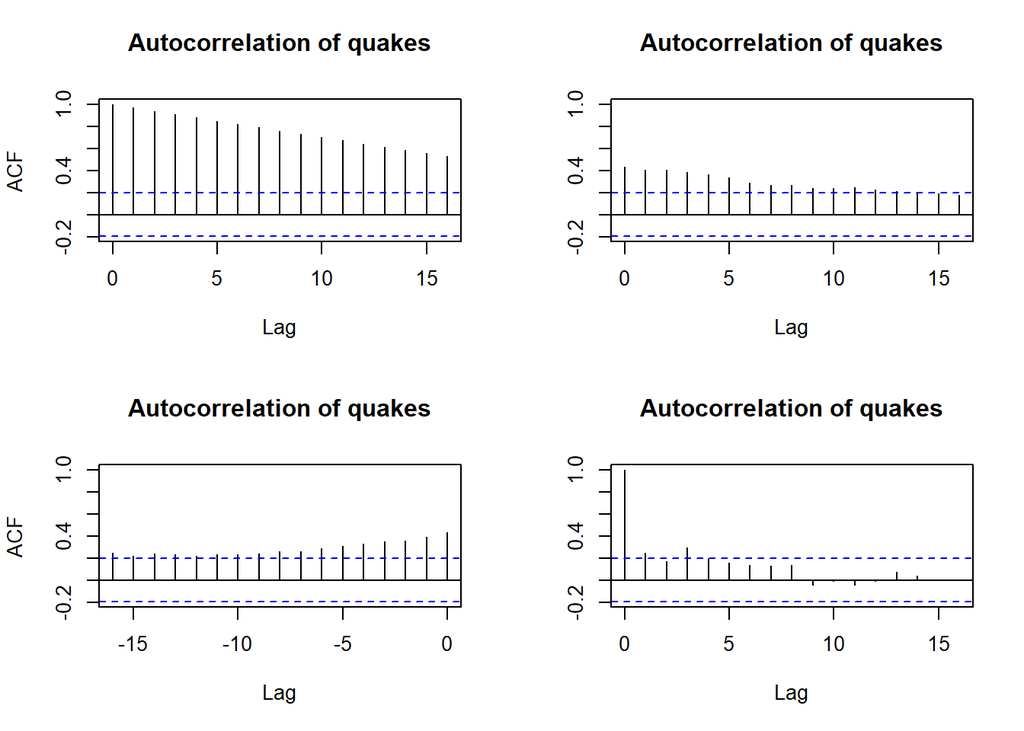

```r
library(ggplot2)
library(astsa)
# Cargar el archivo de datos - Hoja "quakes"
data_quakes <- read_excel("ts.xlsx", sheet = "quakes")

quakes <- data_quakes$quakes

# Convertir los datos a serie de tiempo
ts_quakes <- ts(data_quakes, start = c(2000, 1), frequency = 1)

# Autocorrelación
acf(ts_quakes, main = "Autocorrelation of quakes")
```

```r
# Intentar realizar la descomposición
tryCatch(
  {
    decomposed_quakes <- decompose(ts_quakes)
    plot(decomposed_quakes)
  },
  error = function(e) {

  }
)
```

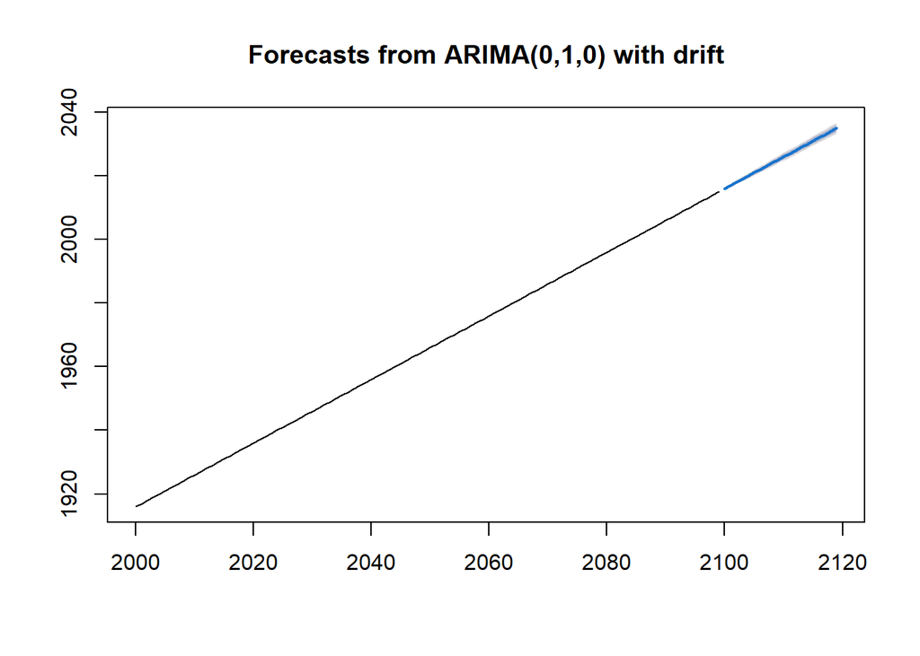

```r
# Modelos de pronóstico ARIMA
model_arima_quakes <- auto.arima(ts_quakes[, 1])
#SARIMA
model_sarima_quakes <- auto.arima(ts_quakes[, 1], seasonal = TRUE)
#ETS
model_ets_quakes <- ets(ts_quakes[, 1])


# Predicción a 20 años
forecast_arima_quakes <- forecast(model_arima_quakes, h = 20)
forecast_sarima_quakes <- forecast(model_sarima_quakes, h = 20)
forecast_ets_quakes <- forecast(model_ets_quakes, h = 20)

#  resultados
plot(forecast_arima_quakes)
plot(forecast_sarima_quakes)
```

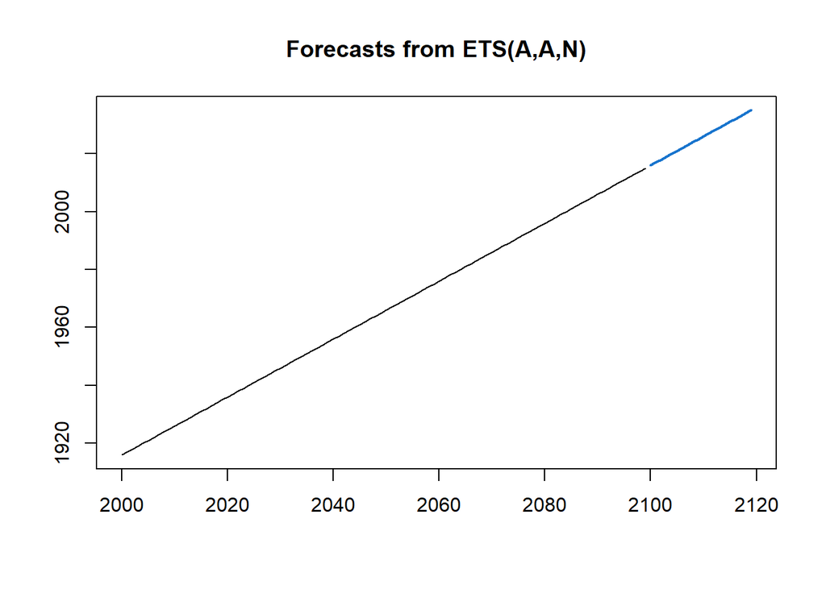

```r
plot(forecast_ets_quakes)
```

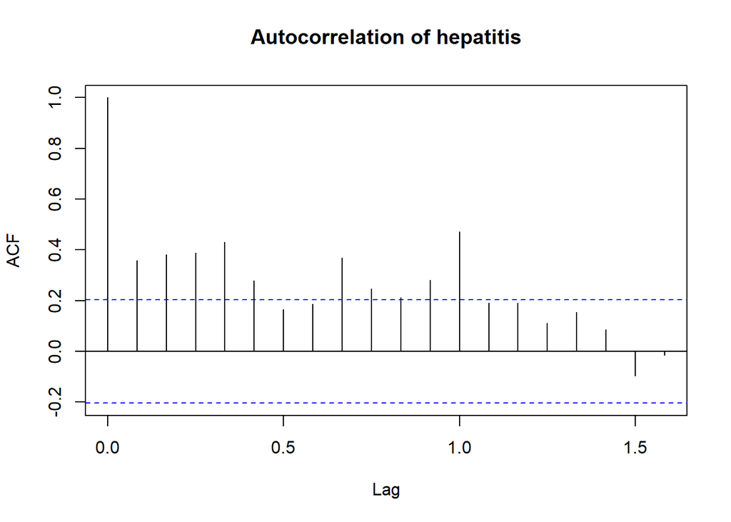

```r
library(readxl)
library(forecast)
library(ggplot2)

# Datos - Hoja "hepatitis"
data_hepatitis <- read_excel("ts.xlsx", sheet = "hepatitis")
# Acomodar la tabla
hepatitis_matrix <- as.matrix(data_hepatitis[, -1])

# Serie de tiempo
ts_hepatitis_univar <- ts(as.vector(hepatitis_matrix), start = c(2010, 1), frequency = 12)

# Eliminación de valores faltantes
ts_hepatitis_univar_clean <- na.omit(ts_hepatitis_univar)

# Realizar el análisis de autocorrelación en la serie de tiempo limpia
acf(ts_hepatitis_univar_clean, main = "Autocorrelation of hepatitis")
```

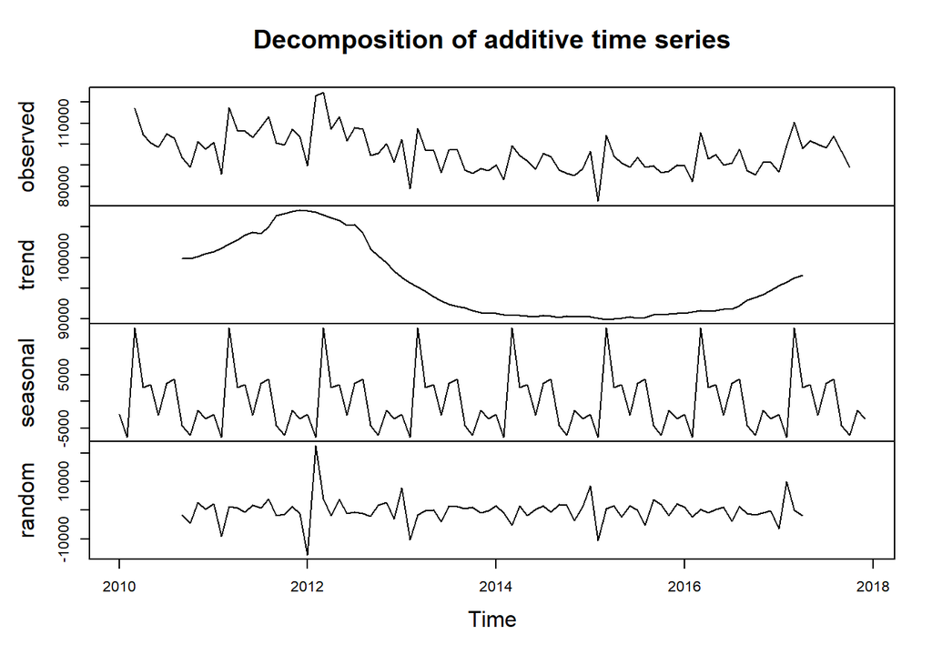

```r
# Descomposición
decomposed_hepatitis <- decompose(ts_hepatitis_univar)
plot(decomposed_hepatitis)
```

```r
# Modelos de pronóstico ARIMA
model_arima_hepatitis <- auto.arima(ts_hepatitis_univar)
#SARIMA
model_sarima_hepatitis <- auto.arima(ts_hepatitis_univar, seasonal = TRUE)
#ETS
model_ets_hepatitis <- ets(ts_hepatitis_univar)
# Validez  modelos
accuracy(model_arima_hepatitis)
```

```
##                    ME     RMSE      MAE      MPE     MAPE      MASE       ACF1
## Training set 86.69843 5617.705 3627.041 0.130229 3.873426 0.5566703 -0.1282956
```

```r
accuracy(model_sarima_hepatitis)
```

```
##                    ME     RMSE      MAE      MPE     MAPE      MASE       ACF1
## Training set 86.69843 5617.705 3627.041 0.130229 3.873426 0.5566703 -0.1282956
```

```r
accuracy(model_ets_hepatitis)
```

```
##                     ME     RMSE      MAE        MPE     MAPE      MASE
## Training set -205.7951 5289.928 3450.878 -0.4657831 3.617529 0.5296332
##                    ACF1
## Training set -0.2173522
```

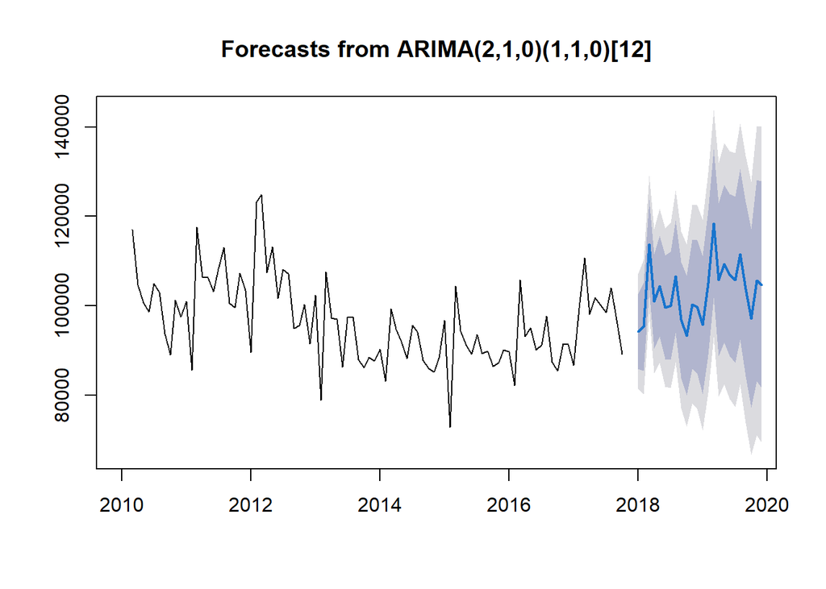

```r
# Predicción a 24 meses
forecast_arima_hepatitis <- forecast(model_arima_hepatitis, h = 24)
forecast_sarima_hepatitis <- forecast(model_sarima_hepatitis, h = 24)
forecast_ets_hepatitis <- forecast(model_ets_hepatitis, h = 24)

# Visualización de los resultados
plot(forecast_arima_hepatitis)
plot(forecast_sarima_hepatitis)
```

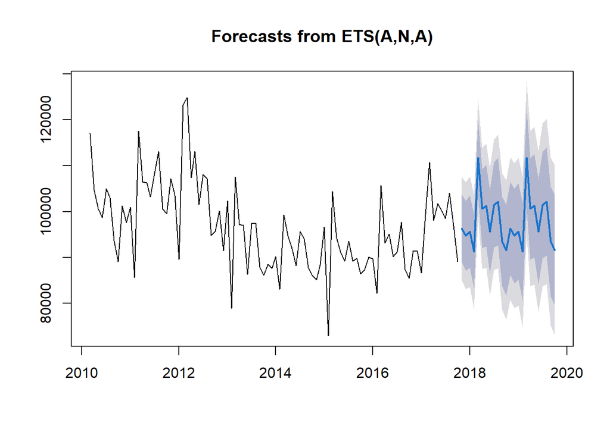

```r
plot(forecast_ets_hepatitis)
```

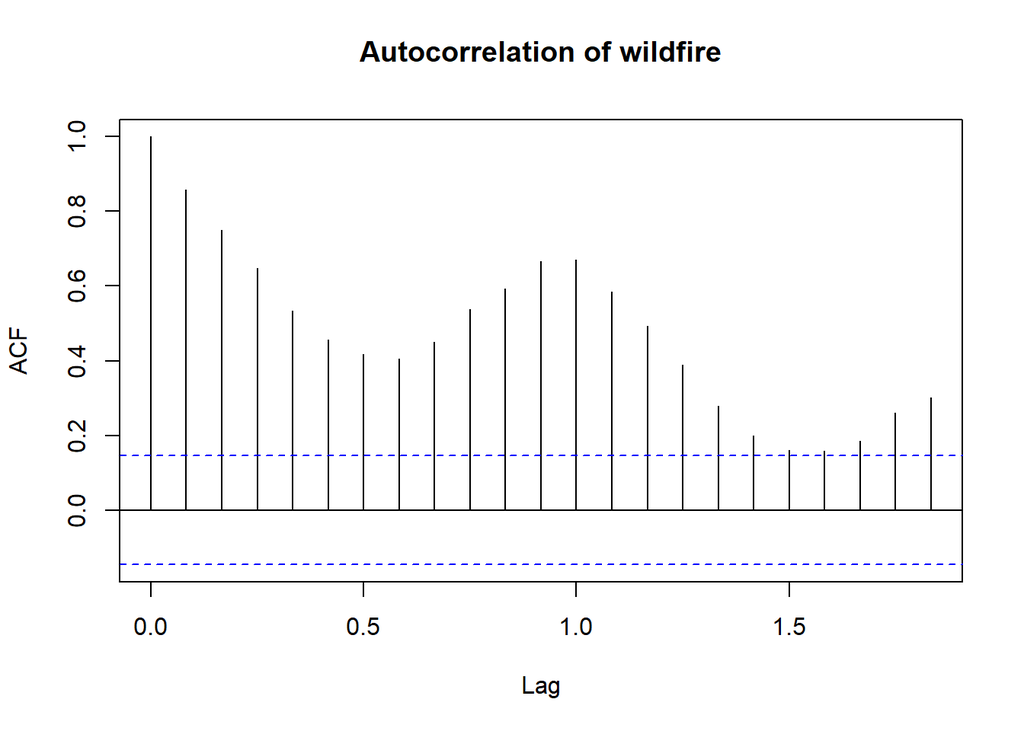

```r
library(readxl)
library(forecast)
library(ggplot2)

# Data - Hoja "wildfire"
data_wildfire <- read_excel("ts.xlsx", sheet = "wildfire")

# Convertir los datos en una serie de tiempo
ts_wildfire <- ts(data_wildfire$`Fire frequency`, start = c(2003, 1), frequency = 12)

# Autocorrelación
acf(ts_wildfire, main = "Autocorrelation of wildfire")
```

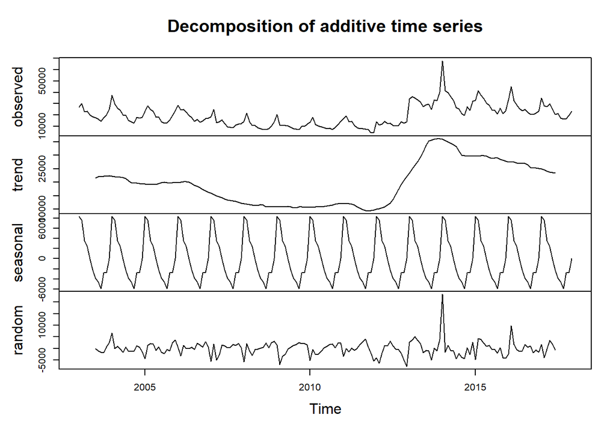

```r
# Descomposición
decomposed_wildfire <- decompose(ts_wildfire)
plot(decomposed_wildfire)
```